# Forecasting of 5 Stock Exchanges with report

## News Impact Curve

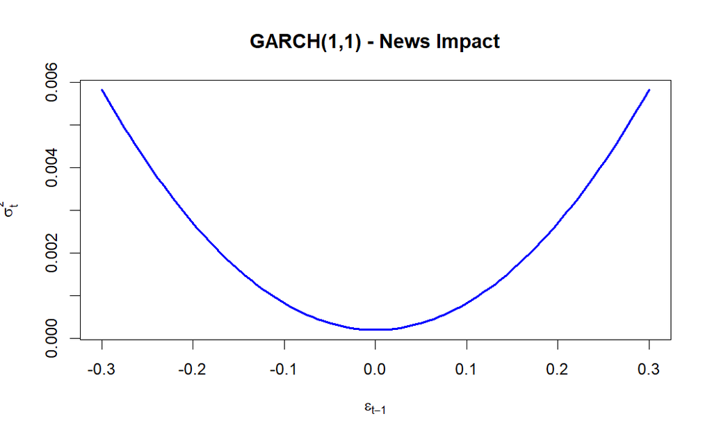

```r
x=newsimpact(x_fit2)
plot(x$zx, x$zy, type="l", lwd=2, col="blue", main="GARCH(1,1) - News Impact", ylab=x$yexpr, xlab=x$xexpr)
```

```r
#to check symmetry
```

## e-GARCH (For asymmetricity)

```r
model3=ugarchspec(variance.model = list(model="eGARCH",garchOrder=c(1,1)),mean.model = list(armaOrder=c(0,0)))
fitmodel2=ugarchfit(model3,data=LRHSI)
fitmodel2
```

```
*---------------------------------*
*          GARCH Model Fit        *
*---------------------------------*

Conditional Variance Dynamics
-----------------------------------
GARCH Model : eGARCH(1,1)
Mean Model  : ARFIMA(0,0,0)
Distribution    : norm

Optimal Parameters
------------------------------------
        Estimate  Std. Error   t value Pr(>|t|)
mu     -0.000512    0.000308   -1.6650 0.095916
omega  -0.253426    0.003643  -69.5693 0.000000
alpha1 -0.077708    0.010569   -7.3525 0.000000
beta1   0.970122    0.000655 1481.3034 0.000000
gamma1  0.109939    0.007070   15.5495 0.000000

Robust Standard Errors:
        Estimate  Std. Error   t value Pr(>|t|)
mu     -0.000512    0.000287   -1.7862 0.074062
omega  -0.253426    0.008901  -28.4730 0.000000
alpha1 -0.077708    0.016703   -4.6523 0.000003
beta1   0.970122    0.000889 1090.8462 0.000000
gamma1  0.109939    0.016012    6.8662 0.000000

LogLikelihood : 4257.981

Information Criteria
------------------------------------

Akaike       -5.7668
Bayes        -5.7488
Shibata      -5.7668
Hannan-Quinn -5.7601

Weighted Ljung-Box Test on Standardized Residuals
------------------------------------
                        statistic p-value
```

[output cut: 22 more lines]

```
------------------------------------
Joint Statistic:  0.8802
Individual Statistics:
mu     0.06104
omega  0.27368
alpha1 0.10943
beta1  0.25550
gamma1 0.06889

Asymptotic Critical Values (10% 5% 1%)
Joint Statistic:         1.28 1.47 1.88
Individual Statistic:    0.35 0.47 0.75

Sign Bias Test
------------------------------------
```

|  | t-value | prob | sig |
| --- | --- | --- | --- |
| Sign Bias | 1.2721869 | 0.2035079 |  |
| Negative Sign Bias | 0.6617474 | 0.5082369 |  |
| Positive Sign Bias | 0.1475119 | 0.8827483 |  |
| Joint Effect | 2.5224322 | 0.4712507 |  |

```
Adjusted Pearson Goodness-of-Fit Test:
------------------------------------
  group statistic p-value(g-1)
1    20     39.59     0.003703
2    30     44.55     0.032553
3    40     51.43     0.087835
4    50     68.02     0.037338


Elapsed time : 0.3814111
```

**Explanation:**

e-GARCH test is done when there is asymmetry in volatility of returns and when there is leverage effect

hence we cannot forecast with e-GARCH model and hence we will forecast the volatility with GARCH model.

```r
#NSEI
ugarchforecast(x_fit2, n.ahead = 5)
```

```
*------------------------------------*
*       GARCH Model Forecast         *
*------------------------------------*
Model: sGARCH
Horizon: 5
Roll Steps: 0
Out of Sample: 0

0-roll forecast [T0=2023-12-29]:
        Series   Sigma
T+1 -0.0001976 0.01394
T+2 -0.0001976 0.01395
T+3 -0.0001976 0.01396
T+4 -0.0001976 0.01397
T+5 -0.0001976 0.01398
```

**NYA**

```r
#step 2: ARCH effect test
ArchTest(LRNYA)  #p-value < 0.05, there is ARCH effect
```

```
    ARCH LM-test; Null hypothesis: no ARCH effects

data:  LRNYA
Chi-squared = 615.83, df = 12, p-value < 2.2e-16
```

```r
#there is ARCH effect

# step3: ARCH/GARCH order
garch(LRNYA, grad="numerical",trace=FALSE)
```

```
Call:
garch(x = LRNYA, grad = "numerical", trace = FALSE)

Coefficient(s):
      a0        a1        b1
0.000102  0.050000  0.050000
```

```r
#step 4: Application of ARCH and GARCH
x=ugarchspec(variance.model = list(garchOrder=c(1,1)),mean.model = list(armaOrder=c(0,0)))
x_fit3=ugarchfit(x,data=LRNYA)
x_fit3
```

```
*---------------------------------*
*          GARCH Model Fit        *
*---------------------------------*

Conditional Variance Dynamics
-----------------------------------
GARCH Model : sGARCH(1,1)
Mean Model  : ARFIMA(0,0,0)
Distribution    : norm

Optimal Parameters
------------------------------------
        Estimate  Std. Error  t value Pr(>|t|)
mu      0.000600    0.000201   2.9880 0.002808
omega   0.000005    0.000002   2.5756 0.010006
alpha1  0.206606    0.022918   9.0148 0.000000
beta1   0.756829    0.011400  66.3902 0.000000

Robust Standard Errors:
        Estimate  Std. Error  t value Pr(>|t|)
mu      0.000600    0.000194  3.08633 0.002026
omega   0.000005    0.000007  0.76561 0.443911
alpha1  0.206606    0.033590  6.15079 0.000000
beta1   0.756829    0.072560 10.43046 0.000000

LogLikelihood : 4905.837

Information Criteria
------------------------------------

Akaike       -6.5011
Bayes        -6.4870
Shibata      -6.5011
Hannan-Quinn -6.4959

Weighted Ljung-Box Test on Standardized Residuals
------------------------------------
                        statistic p-value
Lag[1]                      1.546  0.2137
Lag[2*(p+q)+(p+q)-1][2]     1.701  0.3176
```

[output cut: 19 more lines]

```
Nyblom stability test
------------------------------------
Joint Statistic:  6.4601
Individual Statistics:
mu     0.08416
omega  0.55058
alpha1 0.08279
beta1  0.20619

Asymptotic Critical Values (10% 5% 1%)
Joint Statistic:         1.07 1.24 1.6
Individual Statistic:    0.35 0.47 0.75

Sign Bias Test
------------------------------------
```

|  | t-value | prob | sig |
| --- | --- | --- | --- |
| Sign Bias | 1.314595 | 0.18884650 |  |
| Negative Sign Bias | 0.471295 | 0.63749848 |  |
| Positive Sign Bias | 1.273125 | 0.20317045 |  |
| Joint Effect | 9.711528 | 0.02118434 | ** |

```
Adjusted Pearson Goodness-of-Fit Test:
------------------------------------
  group statistic p-value(g-1)
1    20     53.03    4.625e-05
2    30     67.32    6.993e-05
3    40     91.89    3.704e-06
4    50    105.33    5.364e-06


Elapsed time : 0.2557218
```

**Explanation:**

ARCH test suggests that there is ARCH effect in the data hence we can move ahead to do GARCH forecasting of the series

GARCH gave ARCH,GARCH order of 1,1

Sign Bias Test suggest that there is no significant effect of positive and negative bias individually.

but there is collective effect of both the signs on returns of series. hence there is **asymmetry in volatility of returns**

## News Impact Curve

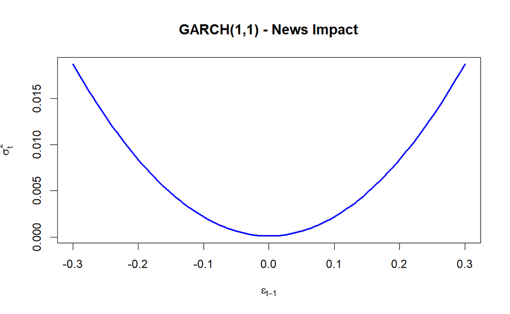

```r
x=newsimpact(x_fit3)
plot(x$zx, x$zy, type="l", lwd=2, col="blue", main="GARCH(1,1) - News Impact", ylab=x$yexpr, xlab=x$xexpr)
```

```r
#to check symmetry
```

## e-GARCH (For asymmetricity)

```r
model4=ugarchspec(variance.model = list(model="eGARCH",garchOrder=c(1,1)),mean.model = list(armaOrder=c(0,0)))
fitmodel3=ugarchfit(model4,data=LRNYA)
fitmodel3
```

```
*---------------------------------*
*          GARCH Model Fit        *
*---------------------------------*

Conditional Variance Dynamics
-----------------------------------
GARCH Model : eGARCH(1,1)
Mean Model  : ARFIMA(0,0,0)
Distribution    : norm

Optimal Parameters
------------------------------------
        Estimate  Std. Error   t value Pr(>|t|)
mu       0.00014    0.000201   0.69766  0.48539
omega   -0.40010    0.058905  -6.79234  0.00000
alpha1  -0.16843    0.019012  -8.85917  0.00000
beta1    0.95672    0.006293 152.02211  0.00000
gamma1   0.25163    0.028633   8.78800  0.00000

Robust Standard Errors:
        Estimate  Std. Error   t value Pr(>|t|)
mu       0.00014    0.000207   0.68008  0.49645
omega   -0.40010    0.071841  -5.56933  0.00000
alpha1  -0.16843    0.031882  -5.28299  0.00000
beta1    0.95672    0.007620 125.55432  0.00000
gamma1   0.25163    0.045681   5.50836  0.00000

LogLikelihood : 4935.773

Information Criteria
------------------------------------

Akaike       -6.5395
Bayes        -6.5219
Shibata      -6.5395
Hannan-Quinn -6.5329

Weighted Ljung-Box Test on Standardized Residuals
------------------------------------
                        statistic p-value
```

[output cut: 22 more lines]

```
------------------------------------
Joint Statistic:  1.4296
Individual Statistics:
mu     0.1337
omega  0.2335
alpha1 0.5058
beta1  0.2269
gamma1 0.4568

Asymptotic Critical Values (10% 5% 1%)
Joint Statistic:         1.28 1.47 1.88
Individual Statistic:    0.35 0.47 0.75

Sign Bias Test
------------------------------------
```

|  | t-value | prob | sig |
| --- | --- | --- | --- |
| Sign Bias | 0.4386983 | 0.6609432 |  |
| Negative Sign Bias | 0.2016155 | 0.8402446 |  |
| Positive Sign Bias | 0.2801397 | 0.7794088 |  |
| Joint Effect | 0.8757171 | 0.8312835 |  |

```
Adjusted Pearson Goodness-of-Fit Test:
------------------------------------
  group statistic p-value(g-1)
1    20     65.79    4.535e-07
2    30     75.95    4.459e-06
3    40     88.71    9.686e-06
4    50    100.42    2.107e-05


Elapsed time : 0.3935001
```

**Explanation:**

e-GARCH test is done when there is asymmetry in volatility of returns and when there is leverage effect

hence we cannot forecast with e-GARCH model and hence we will forecast the volatility with GARCH model.

**Forecasting Volatility in Returns**

```r
#NYA
ugarchforecast(x_fit3, n.ahead = 5)
```

```
*------------------------------------*
*       GARCH Model Forecast         *
*------------------------------------*
Model: sGARCH
Horizon: 5
Roll Steps: 0
Out of Sample: 0

0-roll forecast [T0=2023-12-29]:
       Series    Sigma
T+1 0.0005998 0.007039
T+2 0.0005998 0.007281
T+3 0.0005998 0.007506
T+4 0.0005998 0.007717
T+5 0.0005998 0.007915
```

**N100**

```r
#step 2: ARCH effect test
ArchTest(LRN100)  #p-value < 0.05, there is ARCH effect
```

```
    ARCH LM-test; Null hypothesis: no ARCH effects

data:  LRN100
Chi-squared = 372.17, df = 12, p-value < 2.2e-16
```

```r
#there is ARCH effect

# step3: ARCH/GARCH order
garch(LRN100, grad="numerical",trace=FALSE)
```

```
Call:
garch(x = LRN100, grad = "numerical", trace = FALSE)

Coefficient(s):
       a0         a1         b1
0.0001117  0.0500000  0.0500000
```

```r
#step 4: Application of ARCH and GARCH
x=ugarchspec(variance.model = list(garchOrder=c(1,1)),mean.model = list(armaOrder=c(0,0)))
x_fit4=ugarchfit(x,data=LRN100)
x_fit4
```

```
*---------------------------------*
*          GARCH Model Fit        *
*---------------------------------*

Conditional Variance Dynamics
-----------------------------------
GARCH Model : sGARCH(1,1)
Mean Model  : ARFIMA(0,0,0)
Distribution    : norm

Optimal Parameters
------------------------------------
        Estimate  Std. Error  t value Pr(>|t|)
mu      0.000679    0.000217   3.1290 0.001754
omega   0.000008    0.000001   9.7011 0.000000
alpha1  0.209428    0.024275   8.6274 0.000000
beta1   0.737770    0.020734  35.5828 0.000000

Robust Standard Errors:
        Estimate  Std. Error  t value Pr(>|t|)
mu      0.000679    0.000230   2.9476 0.003203
omega   0.000008    0.000001   6.4120 0.000000
alpha1  0.209428    0.027947   7.4938 0.000000
beta1   0.737770    0.033257  22.1841 0.000000

LogLikelihood : 4943.166

Information Criteria
------------------------------------

Akaike       -6.4312
Bayes        -6.4173
Shibata      -6.4312
Hannan-Quinn -6.4260

Weighted Ljung-Box Test on Standardized Residuals
------------------------------------
                        statistic p-value
Lag[1]                     0.9015  0.3424
Lag[2*(p+q)+(p+q)-1][2]    0.9038  0.5305
```

[output cut: 19 more lines]

```
Nyblom stability test
------------------------------------
Joint Statistic:  12.2069
Individual Statistics:
mu     0.02216
omega  3.51521
alpha1 0.16553
beta1  0.27751

Asymptotic Critical Values (10% 5% 1%)
Joint Statistic:         1.07 1.24 1.6
Individual Statistic:    0.35 0.47 0.75

Sign Bias Test
------------------------------------
```

|  | t-value | prob | sig |
| --- | --- | --- | --- |
| Sign Bias | 2.567795 | 0.0103289458 | ** |
| Negative Sign Bias | 0.399182 | 0.6898147752 |  |
| Positive Sign Bias | 1.362765 | 0.1731571203 |  |
| Joint Effect | 19.447426 | 0.0002209203 | *** |

```
Adjusted Pearson Goodness-of-Fit Test:
------------------------------------
  group statistic p-value(g-1)
1    20     96.47    2.318e-12
2    30    117.01    1.573e-12
3    40    123.69    9.729e-11
4    50    155.02    6.189e-13


Elapsed time : 0.2639291
```

**Explanation:**

ARCH test suggests that there is ARCH effect in the data hence we can move ahead to do GARCH forecasting of the series

GARCH gave ARCH,GARCH order of 1,1

but there is collective effect of both the signs on returns of series. hence there is **asymmetry in volatility of returns**

## News Impact Curve

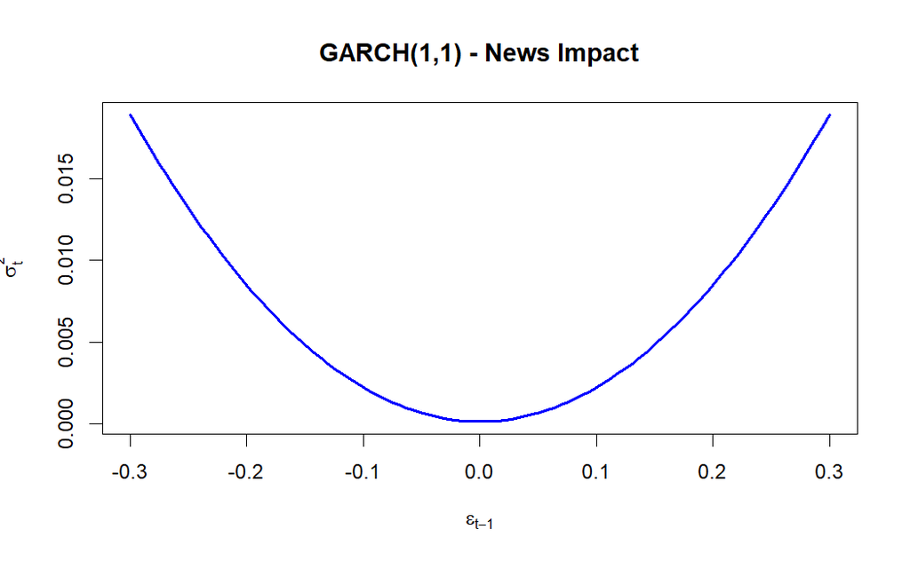

```r
x=newsimpact(x_fit4)
plot(x$zx, x$zy, type="l", lwd=2, col="blue", main="GARCH(1,1) - News Impact", ylab=x$yexpr, xlab=x$xexpr)
```

```r
#to check symmetry
```

## e-GARCH (For asymmetricity)

```r
model5=ugarchspec(variance.model = list(model="eGARCH",garchOrder=c(1,1)),mean.model = list(armaOrder=c(0,0)))
fitmodel4=ugarchfit(model5,data=LRN100)
fitmodel4
```

```
*---------------------------------*
*          GARCH Model Fit        *
*---------------------------------*

Conditional Variance Dynamics
-----------------------------------
GARCH Model : eGARCH(1,1)
Mean Model  : ARFIMA(0,0,0)
Distribution    : norm

Optimal Parameters
------------------------------------
        Estimate  Std. Error   t value Pr(>|t|)
mu      0.000064    0.000206   0.31052  0.75617
omega  -0.490250    0.010384 -47.21374  0.00000
alpha1 -0.187089    0.012848 -14.56204  0.00000
beta1   0.946417    0.001416 668.55202  0.00000
gamma1  0.188821    0.009767  19.33240  0.00000

Robust Standard Errors:
        Estimate  Std. Error   t value Pr(>|t|)
mu      0.000064    0.000190   0.33759  0.73567
omega  -0.490250    0.027547 -17.79661  0.00000
alpha1 -0.187089    0.020168  -9.27631  0.00000
beta1   0.946417    0.002736 345.88459  0.00000
gamma1  0.188821    0.029694   6.35896  0.00000

LogLikelihood : 4981.4

Information Criteria
------------------------------------

Akaike       -6.4797
Bayes        -6.4623
Shibata      -6.4797
Hannan-Quinn -6.4732

Weighted Ljung-Box Test on Standardized Residuals
------------------------------------
                        statistic p-value
```

[output cut: 22 more lines]

```
------------------------------------
Joint Statistic:  1.0781
Individual Statistics:
mu     0.27220
omega  0.32520
alpha1 0.05221
beta1  0.30107
gamma1 0.36109

Asymptotic Critical Values (10% 5% 1%)
Joint Statistic:         1.28 1.47 1.88
Individual Statistic:    0.35 0.47 0.75

Sign Bias Test
------------------------------------
```

|  | t-value | prob | sig |
| --- | --- | --- | --- |
| Sign Bias | 2.1356059 | 0.03286983 | ** |
| Negative Sign Bias | 1.1236109 | 0.26135427 |  |
| Positive Sign Bias | 0.7299229 | 0.46554901 |  |
| Joint Effect | 8.9588772 | 0.02984266 | ** |

```
Adjusted Pearson Goodness-of-Fit Test:
------------------------------------
  group statistic p-value(g-1)
1    20     74.44    1.654e-08
2    30     87.28    9.485e-08
3    40    104.10    7.754e-08
4    50    120.51    5.872e-08


Elapsed time : 0.3309391
```

**Explanation:**

e-GARCH test is done when there is asymmetry in volatility of returns and when there is leverage effect

hence we cannot forecast with e-GARCH model and hence we will forecast the volatility with GARCH model.

```r
#NSEI
ugarchforecast(x_fit4, n.ahead = 5)
```

```
*------------------------------------*
*       GARCH Model Forecast         *
*------------------------------------*
Model: sGARCH
Horizon: 5
Roll Steps: 0
Out of Sample: 0

0-roll forecast [T0=2023-12-29]:
       Series    Sigma
T+1 0.0006786 0.005967
T+2 0.0006786 0.006434
T+3 0.0006786 0.006847
T+4 0.0006786 0.007216
T+5 0.0006786 0.007550
```